# NBA fitting Lasso

Podemos estudiar dónde se encuentran las relaciones más fuertes y evidentes entre las variables; para ello, implementaré el cálculo de la matriz de correlaciones de las diferentes variables entre sí (con `salary` en logaritmos):

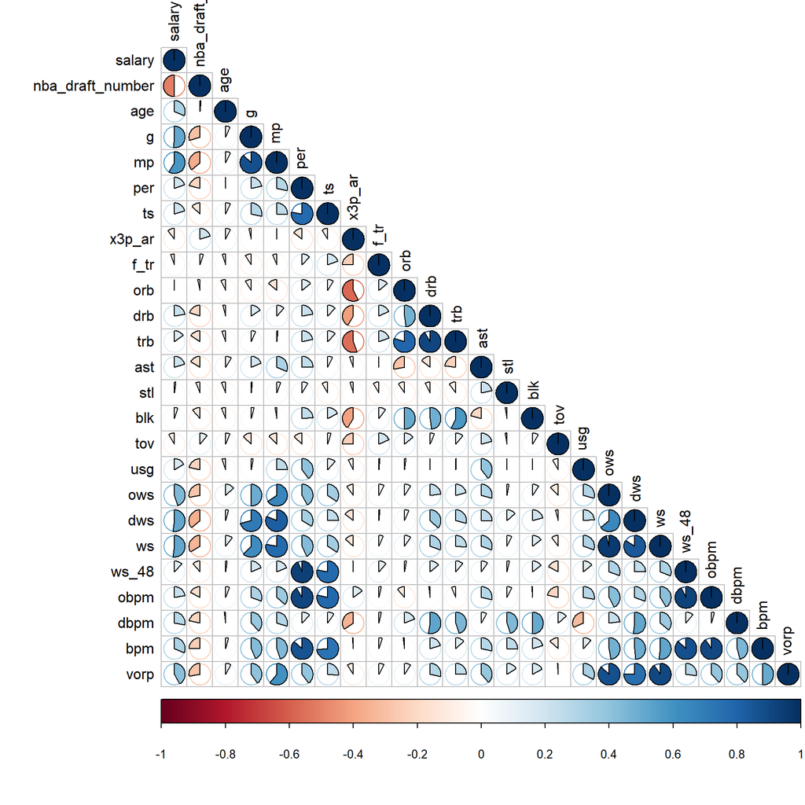

```r
corrplot(cor(log_nba %>%
               select_at(vars(- c("player", "nba_country", "tm")))),
         method = "pie",
         type = "lower",
         tl.col = "black")
```

Podría haber sido útil, en un principio, graficar las dispersiones entre variables junto con los valores de correlación más significativos. Esto lo conseguimos a través del comando *chart.Correlation*:

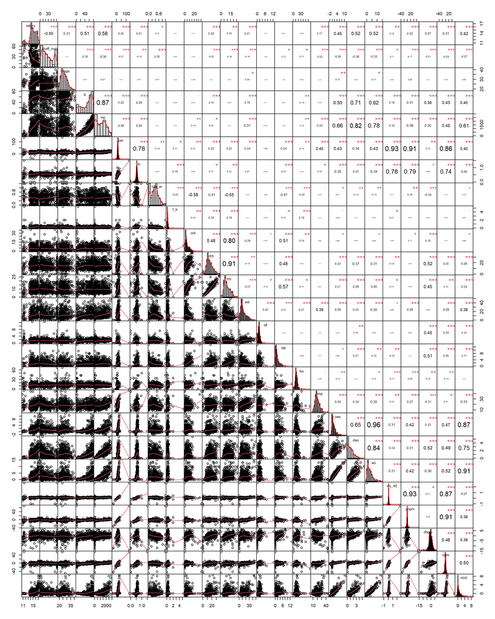

```r
chart.Correlation(log_nba %>%
                    select_at(vars(-c("player", "nba_country", "tm"))),
                  histogram = TRUE)
```

### Análisis de los valores del VIF.

Una vez hemos llevado a cabo un pequeño análisis descriptivo de las principales características y relaciones de las variables frente al target, podemos analizar el factor de inflación de la varianza (o **VIF`**), que nos dará información sobre la posible colinalidad de los datos.

```r
VIF_nba <- lm(salary~.-player-nba_country-tm, data = log_nba)

valores <- car::vif(VIF_nba)

knitr::kable(valores)
```

|  | x |
| --- | --- |
| nba_draft_number | 1.340170 |
| age | 1.078945 |
| g | 6.999197 |
| mp | 14.172245 |
| per | 110.918970 |
| ts | 6.146914 |
| x3p_ar | 5.301979 |
| f_tr | 1.264400 |
| orb | 317.236811 |
| drb | 684.388198 |
| trb | 1439.666086 |
| ast | 3.445392 |
| stl | 3.208627 |
| blk | 5.305430 |
| tov | 1.917591 |
| usg | 6.861721 |
| ows | 1329.661494 |
| dws | 405.100887 |
| ws | 2683.730741 |
| ws_48 | 67.930181 |
| obpm | 10524.307876 |
| dbpm | 2307.119717 |
| bpm | 12928.849699 |
| vorp | 11.551583 |

A la vista de los resultados del VIF que aparecen en la tabla, se ve como hay algunos valores desorbitados. En particular, son especialmente preocupantes los valores de: `per`, `orb`, `drb`, `trb`, `ows`, `dws`, `ws`, `obpm`, `dbpm`, `bpm`.

### Selección de un modelo:

Lo primero que haré a continuación será eliminar del dataframe `log_nba` todas las variables que son categóricas (`Player`, `Nba_Counry` y `tm`).

```r
log_nba <- log_nba %>%
                  select_at(vars(-c("player","nba_country", "tm")))

set.seed(1234)

num_datos <- nrow(log_nba)

num_datos_test <- 10

prueba = sample(num_datos ,
                num_datos - num_datos_test)

datos_prueba <- log_nba[prueba, ]

datos_test <- log_nba[-prueba, ]

modelo <- regsubsets(salary~.,
                     data = datos_prueba,
                     method = 'seqrep',
                     nvmax = 24)

resumen_modelo <- summary(modelo)

data.frame(
  R2 = (resumen_modelo$adjr2),
  CP = (resumen_modelo$cp),
  BIC = (resumen_modelo$bic)
)
```

```
##           R2         CP       BIC
## 1  0.3343986 197.010700 -180.4207
## 2  0.3427559 189.275294 -181.2226
## 3  0.4689934  64.478556 -276.5305
## 4  0.5197487  15.038921 -318.7043
## 5  0.5198819  15.885572 -313.6920
## 6  0.5195917  17.150815 -308.2664
## 7  0.5247299  13.068604 -308.1925
## 8  0.5282683  10.580383 -306.5757
## 9  0.5296188  10.252640 -302.7918
## 10 0.5314565   9.453954 -299.5035
## 11 0.5196195  22.014259 -282.6224
## 12 0.5336976   9.277353 -291.5043
## 13 0.5359619   8.084398 -288.6717
## 14 0.5368847   8.202266 -284.4861
## 15 0.5211708  24.425576 -263.6490
## 16 0.5365726  10.533536 -273.9294
## 17 0.5357785  12.312904 -268.0068
## 18 0.5349564  14.115848 -262.0595
## 19 0.5182523  31.151311 -240.3265
## 20 0.5336593  17.379042 -250.5266
## 21 0.5327367  19.268277 -244.4886
## 22 0.5315936  21.363615 -238.2331
## 23 0.5308905  23.035809 -232.4243
## 24 0.5298764  25.000000 -226.3072
```

```r
resumen_modelo$outmat
```

```
##           nba_draft_number age g   mp  per ts  x3p_ar f_tr orb drb trb ast stl
## 1  ( 1 )  " "              " " " " "*" " " " " " "    " "  " " " " " " " " " "
## 2  ( 1 )  "*"              "*" " " " " " " " " " "    " "  " " " " " " " " " "
## 3  ( 1 )  "*"              "*" "*" " " " " " " " "    " "  " " " " " " " " " "
## 4  ( 1 )  "*"              "*" " " "*" " " " " " "    " "  " " "*" " " " " " "
## 5  ( 1 )  "*"              "*" " " "*" " " " " " "    " "  " " "*" " " " " " "
## 6  ( 1 )  "*"              "*" " " "*" " " " " " "    " "  " " "*" " " " " " "
## 7  ( 1 )  "*"              "*" " " "*" "*" " " " "    " "  " " " " "*" " " " "
## 8  ( 1 )  "*"              "*" " " "*" "*" "*" " "    " "  " " "*" " " " " " "
## 9  ( 1 )  "*"              "*" " " "*" "*" "*" " "    " "  " " " " "*" " " " "
## 10  ( 1 ) "*"              "*" " " "*" "*" "*" "*"    " "  " " "*" " " " " " "
## 11  ( 1 ) "*"              "*" "*" "*" "*" "*" "*"    "*"  "*" "*" "*" " " " "
## 12  ( 1 ) "*"              "*" " " "*" "*" "*" "*"    " "  " " "*" " " " " " "
## 13  ( 1 ) "*"              "*" "*" "*" "*" "*" " "    " "  " " " " "*" "*" " "
## 14  ( 1 ) "*"              "*" "*" "*" "*" "*" " "    "*"  " " " " "*" "*" " "
```

[output cut: 35 more lines]

Dentro de los modelos que escojamos, debemos tener en cuenta que los ajustes serán mejores a medida que $R^{2}$ sea mayor, pero CP y BIC sean menores.

De acuerdo con esto, el modelo que deberíamos escoger en función del $R^{2}$, CP y BIC serían, respectivamente:

```r
data.frame(
  Adj.R2 = which.max(resumen_modelo$adjr2),
  CP = which.min(resumen_modelo$cp),
  BIC = which.min(resumen_modelo$bic)
)
```

```
##   Adj.R2 CP BIC
## 1     14 13   4
```

```r
mejorR2 <- coef(modelo, which.max(resumen_modelo$adjr2))
mejorCP <- coef(modelo, which.min(resumen_modelo$cp))
mejorBIC <- coef(modelo, which.min(resumen_modelo$bic))
```

Para el caso del ajuste por $R^{2}$ tenemos que las variables que deberíamos considerar son: `nba_draft_number`, `age`, `g`, `mp`, `per`, `ts`, `f_tr`, `trb`, `ast`, `tov`, `usg`, `dws`, `ws_48`, `dbpm`.

En el caso del ajuste por CP: `nba_draft_number`, `age`, `g`. `mp`, `per`, `ts`, `trb`, `ast`, `tov`, `usg`, `dws`, `ws_48`, `dbpm`.

Por último, en el caso del BIC: `nba_draft_number`, `age`, `mp` y `drb`.

#### Estudio de los modelos:

Vamos a implementar los diferentes análisis de los modelos linales en función de cada uno de los métodos seleccionados:

```r
CPnba <- lm(salary ~ nba_draft_number + age + mp + per + ts + trb + ast + tov + usg + dws +ws_48 + dbpm, data = datos_prueba)

BICnba <- lm(salary ~ nba_draft_number + age + mp + drb, data = datos_prueba)

R2nba <- lm(salary ~ nba_draft_number + age + mp + per + ts + f_tr + trb + ast + tov + usg + dws +ws_48 + dbpm, data = datos_prueba)
```

```r
R2prediccion <- predict(R2nba, newdata = datos_test)
CPprediccion <- predict(CPnba, newdata = datos_test)
BICprediccion <- predict(BICnba, newdata = datos_test)

cbind(datos_test$salary, R2prediccion, CPprediccion, BICprediccion)
```

```
##              R2prediccion CPprediccion BICprediccion
## 8   10.73813     12.75007     12.75624      12.81815
## 27  15.00640     16.19503     16.19885      16.08326
## 32  13.61170     14.00431     13.98739      13.91118
## 44  16.55332     15.56626     15.56882      15.60099
## 144 14.20171     14.56405     14.59334      14.74093
## 183 14.22401     13.76261     13.77870      13.92808
## 434 14.71210     13.75832     13.76199      13.91641
## 436 14.10156     14.07144     14.04792      14.14277
## 457 11.43128     12.97999     13.01765      12.97544
## 480 15.52106     15.72969     15.73343      15.80329
```

```r
data.frame(Salarios = exp(datos_test$salary), Prediccion_R2 = exp(R2prediccion), Prediccion_CP = exp(CPprediccion), Prediccion_BIC = exp(BICprediccion))
```

```
##     Salarios Prediccion_R2 Prediccion_CP Prediccion_BIC
## 8      46080      344577.7      346708.3       368850.6
## 27   3290000    10799662.8    10841090.8      9657631.3
## 32    815615     1207803.7     1187533.6      1100400.1
## 44  15453126     5758891.0     5773654.5      5962422.9
## 144  1471382     2113916.5     2176738.0      2522917.6
## 183  1504560      948474.6      963855.4      1119148.8
## 434  2451225      944415.7      947886.0      1106169.2
## 436  1331160     1291664.2     1261636.1      1387156.7
## 457    92160      433648.9      450289.4       431680.4
## 480  5504420     6781374.8     6806752.4      7299291.2
```

## Validaciones del modelo

### Elastic Net:

Queremos implementar un modelo elastic net para validar nuestras predicciones y variables escogidas. Para ello, deberemos escoger aquellos valores que $\alpha$ que minimicen el valor de $\lambda$. Esto lo conseguimos creando variables vacías e iterando en un bucle para ir rellenándolas con los valores de $\lambda$.

```r
set.seed(123)

ames_split <- initial_split(AmesHousing::make_ames(), prop = .7, strata = "Sale_Price")
ames_train <- training(ames_split)
ames_test  <- testing(ames_split)
```

Dividimos los datos en dos muestras: una para hacer el training del modelo y otra para evaluar (testing) el mismo.

```r
set.seed(123)

splitted_nba <- initial_split(log_nba, prop = 0.7, strata = 'salary')

nba_prueba <- training(splitted_nba)

nba_test <- testing(splitted_nba)

dim(nba_prueba)
```

```
## [1] 339  25
```

```r
dim(nba_test)
```

```
## [1] 142  25
```

Comprobamos que tienen las mismas dimensiones para las columnas (es necesario que así sea).

En este punto es muy importante asegurarnos de que en los datos que le introducimos al *model.matrix* **no haya variables categóricas**, pues si no (como a mi me ocurría en un principio) no coincidirán nunca las dimensiones, ya que *model.matrix* crea variables dummies por sí misma; si dejamos las categóricas no va a funcionar.

```r
#Eliminamos la pendiente:

nba_train_x <- model.matrix(salary ~., data = nba_prueba)[, -1]

nba_train_y <- nba_prueba$salary

nba_test_x <- model.matrix(salary ~., data = nba_test)[, -1]

nba_test_y <- nba_test$salary

#Calculamos las dimensiones:

dim(nba_test_x)
```

```
## [1] 142  24
```

```r
dim(nba_train_x)
```

```
## [1] 339  24
```

Nos aseguramos de que tienen las mismas dimensiones **en las columnas**.

Creamos la *net* para la evaluación de los modelos haciendo un *tunning* para la elección de $\lambda$ y $\alpha$ a través del bucle de las diapositivas de clase:

```r
fold_id <- sample(1:10, size = length(nba_train_y), replace = TRUE)

tuning_grid <- tibble::tibble(
  alpha      = seq(0, 1, by = .1),
  mse_min    = NA,
  mse_1se    = NA,
  lambda_min = NA,
  lambda_1se = NA
)

for (i in seq_along(tuning_grid$alpha)) {

  fit <- cv.glmnet(nba_train_x, nba_train_y, alpha = tuning_grid$alpha[i], foldid = fold_id)

  # extract MSE and lambda values
  tuning_grid$mse_min[i]    <- fit$cvm[fit$lambda == fit$lambda.min]
  tuning_grid$mse_1se[i]    <- fit$cvm[fit$lambda == fit$lambda.1se]
  tuning_grid$lambda_min[i] <- fit$lambda.min
  tuning_grid$lambda_1se[i] <- fit$lambda.1se
}

tuning_grid
```

```
## # A tibble: 11 x 5
##    alpha mse_min mse_1se lambda_min lambda_1se
##    <dbl>   <dbl>   <dbl>      <dbl>      <dbl>
##  1   0      1.25    1.37     0.267       1.89
##  2   0.1    1.21    1.32     0.370       1.24
##  3   0.2    1.19    1.30     0.269       0.820
##  4   0.3    1.17    1.27     0.216       0.600
##  5   0.4    1.16    1.27     0.162       0.494
##  6   0.5    1.16    1.25     0.142       0.395
##  7   0.6    1.15    1.26     0.130       0.361
##  8   0.7    1.15    1.25     0.111       0.310
##  9   0.8    1.15    1.26     0.0974      0.297
## 10   0.9    1.15    1.25     0.0866      0.264
## 11   1      1.14    1.24     0.0779      0.238
```

De la tabla obtenida anteriormente, se ve cómo el mejor modelo es el que presenta $\alpha = 1$ es el mejor (recordemos que el modelo $\alpha = 1$ es el modelo Lasso). Podemos hacer un plot con los diferentes modelos junto con su desviación estándar para ver lo que ocurre al escoger los valores de $\alpha$ y $\lambda$:

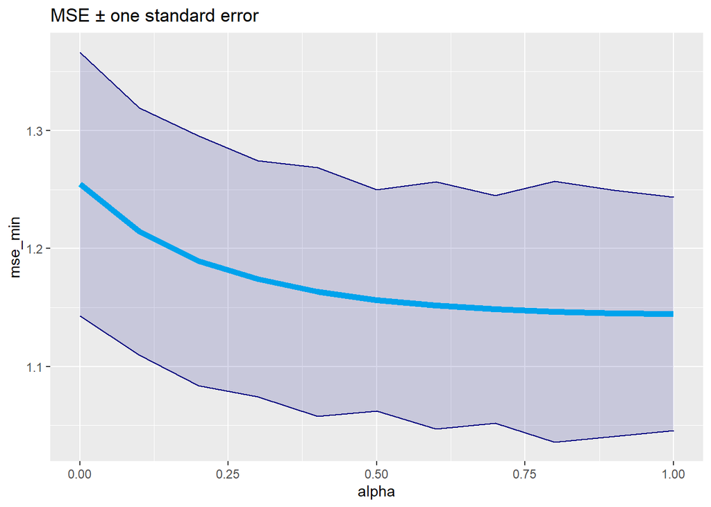

```r
tuning_grid %>%
  mutate(se = mse_1se - mse_min) %>%
    ggplot(aes(alpha, mse_min)) +
      geom_line(size = 2, color = 'Deepskyblue') +
      geom_ribbon(aes(ymax = mse_min + se, ymin = mse_min - se), alpha = .15, fill = 'navy', color = 'navy') +
      ggtitle("MSE ± one standard error")
```

Estamos representando los diferentes valores de $\alpha$ y $\lambda$ junto con un intervalo de confianza que nos ha proporcionado el bucle para el `MSE`. Vemos que, en principio, todos losvalores se encuentran dentro de dicho intervalo.

## Predicción

A continuación, implementaré los diferentes modelos que he obtenido a lo largo de la práctica para realizar una predicción sobre los datos.

```r
cv_alpha1 <- cv.glmnet(nba_train_x, nba_train_y, alpha = 1)

min(cv_alpha1$cvm)
```

```
## [1] 1.135421
```

```r
#Probaremos con otro alpha, pues a partir de 0.5 el error no cambia de forma considerable.

cv_alpha06 <- cv.glmnet(nba_train_x, nba_train_y, alpha = 0.6)

min(cv_alpha06$cvm)
```

```
## [1] 1.167842
```

- Para el caso de $\alpha = 0.6$:

```r
prediccion <- predict(cv_alpha06, s = cv_alpha06$lambda.min, nba_test_x)

nba_test$Prediccion <- exp(prediccion)

mean((nba_test_y - prediccion)^2)
```

```
## [1] 1.078909
```

- Para el caso de $\alpha = 1$:

```r
prediccion_alpha1 <- predict(cv_alpha1, s = cv_alpha1$lambda.min, nba_test_x)

nba_test$Prediccion_alpha1 <- exp(prediccion_alpha1)

mean((nba_test_y - prediccion_alpha1)^2)
```

```
## [1] 1.06752
```